# Zero-inflated Poisson Analysis of Bluebird Counts

BIO 133

Eric R. Scott

# Packages

Packages you’ll need:

```r
library(tidyverse)
library(here) # for here()
library(pscl) #for zero-inflated poisson
library(MASS) #for rnegbin() and other useful functions
select <- dplyr::select
#optional:
library(maps)
library(mapproj)
```

# Data

```r
# data for map
new_england <- map_data('state', region = c('massachusetts', 'new hampshire', 'vermont', 'maine', 'connecticut', 'rhode island'))

# bluebirds.csv on canvas
birds2 <- read_csv(here("data", "bluebirds.csv"))
head(birds2)
```

| Code | Latitude | Longitude | hours | count |
| --- | --- | --- | --- | --- |
| CTBA | 41.9123 | -72.9884 | 72.50 | 127 |
| CTEW | 41.7966 | -71.9274 | 48.50 | 72 |
| CTGS | 41.0826 | -73.6138 | 182.50 | 60 |
| CTHA | 41.7660 | -72.6727 | 198.00 | 31 |
| CTLH | 41.7703 | -73.2724 | 69.95 | 122 |
| CTLS | 41.9449 | -73.4399 | 49.50 | 65 |

# Inspect data

## Map

Totally optional. Dont’ worry if you can’t get it to work.

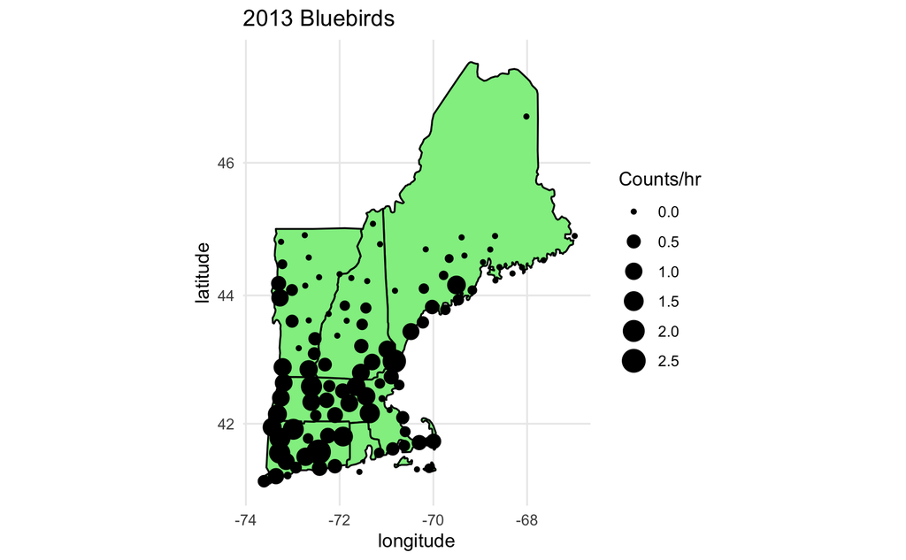

```r
ggplot() +
  geom_polygon(data = new_england, aes(x = long, y = lat, group = group),
               color = "black", #lines
               fill = "lightgreen") + #area
  geom_point(data = birds2, aes(x = Longitude, y = Latitude, size = count/hours)) +
  coord_map() +
  theme_minimal() +
  labs(title = "2013 Bluebirds", x = "longitude", y = "latitude", size = "Counts/hr")
```

## Plot of zeros

The zeros in the data might be because bluebirds have migrated south for the winter during the Christmas bird count. Or, it could be that we just didn’t happen to see any bluebirds in that location (but they are around). Does the probability of seeing a bluebird vary with lattitude?

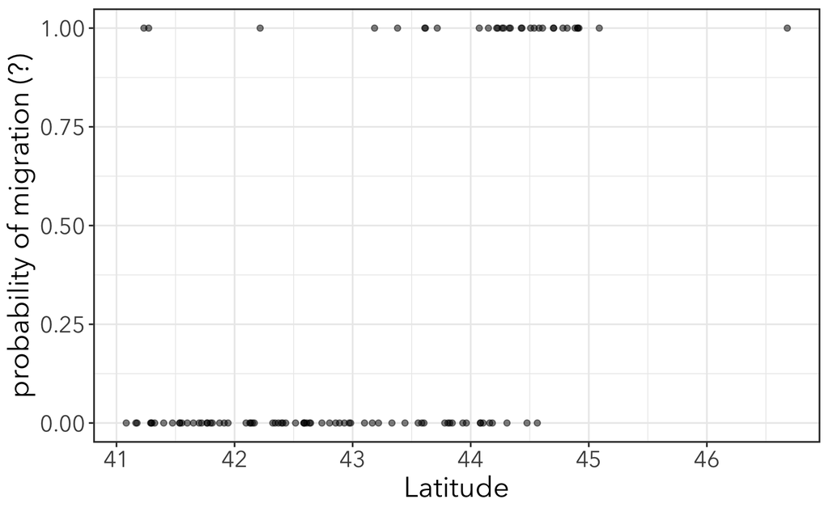

```r
#create column of 1's and 0's (TRUE is converted to 1 and FALSE is converted to 0)
birds2 <- birds2 %>%
  mutate(zero = as.numeric(count == 0))

#plot
migration_plot <- ggplot(birds2, aes(x = Latitude, y = zero)) +
  geom_point(alpha = 0.5) #make points slightly transparent to see overplotting better.
migration_plot + labs(y = "probability of migration (?)")
```

## Do we think these counts might be overdispersed?

```r
summary(m1)
```

[output not shown]

# Regular Poisson

Fit a poisson GLM with an offset of log(hours) to estimate a trend in birds per hour with lattitude.

```r
m_pois <- glm(count ~ Latitude, offset = log(hours), family = poisson, data = birds2)
```

What is the expected number of birds per hour? Per 100 hours?

# Zero-inflated Poisson

Fit three ZiP GLMs:

1. Latitude affects both count and zeros

```r
m_zip1 <- zeroinfl(count ~ Latitude|Latitude, offset = log(hours), data = birds2)
```

2. Latitude affects only zeros (i.e. probability that birds have migrated)

```r
m_zip2 <- zeroinfl(count ~ 1|Latitude, offset = log(hours), data = birds2)
```

3. Latitude affects only count (i.e. average #birds per hour)

```r
m_zip3 <-zeroinfl(count ~ Latitude|1, offset = log(hours), data = birds2)
```

```r
AIC(m_zip1, m_zip2, m_zip3, m_pois)
```

|  | df | AIC |
| --- | --- | --- |
| m_zip1 | 4 | 3343.710 |
| m_zip2 | 3 | 3381.176 |
| m_zip3 | 3 | 3383.727 |
| m_pois | 2 | 4626.149 |

```r
summary(m_zip1)
```

```
Call:
zeroinfl(formula = count ~ Latitude | Latitude, data = birds2,
    offset = log(hours))

Pearson residuals:
    Min      1Q  Median      3Q     Max
-5.8386 -0.8410 -0.4654  1.3458 11.1083

Count model coefficients (poisson with log link):
            Estimate Std. Error z value Pr(>|z|)
(Intercept)  4.06875    0.71131   5.720 1.06e-08 ***
Latitude    -0.10450    0.01677  -6.232 4.62e-10 ***

Zero-inflation model coefficients (binomial with logit link):
            Estimate Std. Error z value Pr(>|z|)
(Intercept) -67.1789    13.8141  -4.863 1.16e-06 ***
Latitude      1.5278     0.3158   4.838 1.31e-06 ***
---
Signif. codes:  0 '***' 0.001 '**' 0.01 '*' 0.05 '.' 0.1 ' ' 1

Number of iterations in BFGS optimization: 11
Log-likelihood: -1668 on 4 Df
```

# Negative Binomial Distribution

Try changing theta and see what it does:

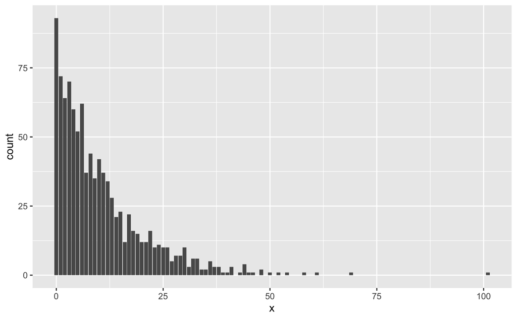

```r
df <- tibble(x = rnegbin(1000, mu = 10, theta = 1))
ggplot(df, aes(x)) +
  geom_bar()
```

## Fit a Negative Binomial GLM

Fit a negative binomial glm with glm.nb() (also estimating trend with latitude)

[output not shown]

What is the expected number of birds per hour?

# Zero-inflated Negative Binomial

If there is time, fit the three models you did for the zero-inflated poisson, but with a zero-inflated negative binomial error distribution.

1. Latitude affects both count and zeros

```r
m_zinb1
```

[output not shown]

2. Latitude affects only zeros (i.e. probability that birds have migrated)

```r
m_zinb2 <- zeroinfl(count ~ 1|Latitude, offset = log(hours), dist = "negbin", data = birds2)
```

3. Latitude affects only count (i.e. average #birds per hour)

```r
m_zinb3 <-zeroinfl(count ~ Latitude|1, offset = log(hours), dist = "negbin", data = birds2)
```

## Model comparison

Use AIC to compare the models you fit

```r
bbmle::ICtab(m_zip1, m_zip2, m_zip3, m_pois, m_nb, m_zinb1, m_zinb2, m_zinb3)
```

```
        dAIC   df
m_zinb1    0.0 5
m_zinb2    1.1 4
m_zinb3   43.1 4
m_zip1  2552.3 4
m_zip2  2589.8 3
m_zip3  2592.4 3
m_pois  3834.8 2
m_nb    3836.6 3
```

```r
summary(m_zinb1)
```

```
Call:
zeroinfl(formula = count ~ Latitude | Latitude, data = birds2,
    offset = log(hours), dist = "negbin")

Pearson residuals:
    Min      1Q  Median      3Q     Max
-1.0181 -0.4953 -0.2211  0.4455  2.9739

Count model coefficients (negbin with log link):
            Estimate Std. Error z value Pr(>|z|)
(Intercept) 10.29144    5.89161   1.747   0.0807 .
Latitude    -0.25089    0.13837  -1.813   0.0698 .
Log(theta)   0.06656    0.19593   0.340   0.7341

Zero-inflation model coefficients (binomial with logit link):
             Estimate Std. Error z value Pr(>|z|)
(Intercept) -123.7546    43.8517  -2.822  0.00477 **
Latitude       2.8081     0.9928   2.829  0.00468 **
---
Signif. codes:  0 '***' 0.001 '**' 0.01 '*' 0.05 '.' 0.1 ' ' 1

Theta = 1.0688
Number of iterations in BFGS optimization: 310
Log-likelihood: -390.7 on 5 Df
```

## Plot migration probability as function of lattitude

```r
pred_data <-
  tibble(
  Lattitude = seq(min(birds2$Latitude), max(birds2$Latitude), 0.05),
  prob = plogis(coef(w3)[2] + coef(w3)[3]*Lattitude)
  )
```

Plot the predicted line on our presence/absence plot from before

```r
migration_plot +
  geom_line(data = pred_data, aes(x = Lattitude, y = prob)) +
  labs(y = "probability of migration")
```

[output not shown]